# Stats102A_Hw1

Qingfeng Zou

2020/1/18

source(“004997640_stats102a_hw1.R”)

### Question 1:

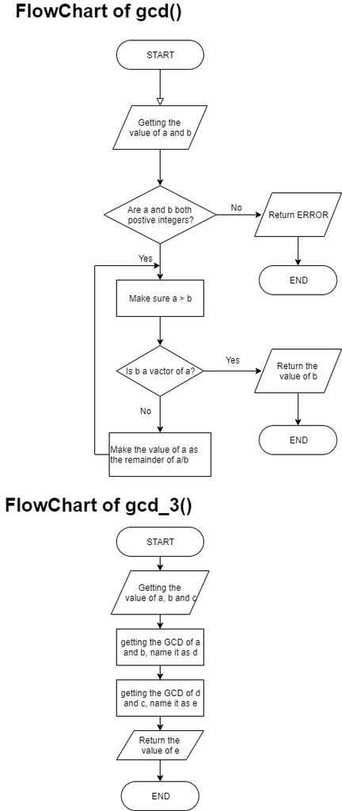

Question 1 Flowchart

#### Pseudocode of Question 1:

gcd():  
__take in two variable a and b  
__if a and b are not numeric, return ERROR  
__if a and b are not positive integers, return ERROR  
__if a < b, change the values between a and b  
__if the remainder of a/b is 0, return b  
__do gcd again with b and the remainder of a/b, return its result(return value)

gcd_3()  
__take in variables a, b and c  
__use gcd function to get the GCD between a and b  
__use gcd function to get the GCD between c and, the GCD between a and b, return the result.

### Question 2:

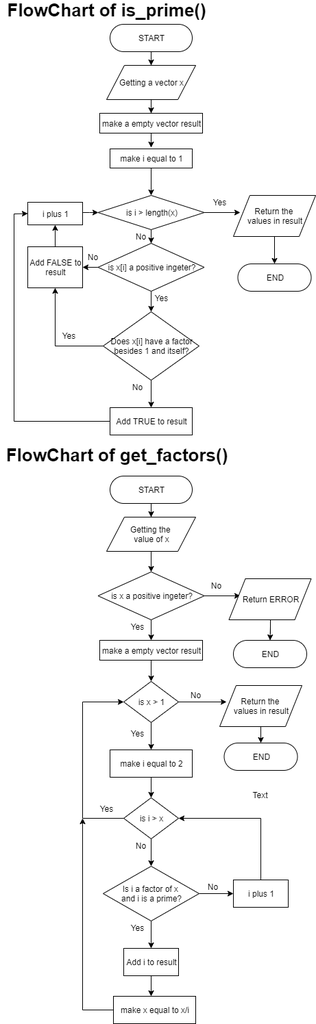

Question2 Flowchart

#### Pseudocode of Question 2:

is_prime():  
take in vector x  
make result an empty vector  
for loop with variable i from 1 to the length of x  
if x[i] isn’t a numeric  
add FALSE to result  
goto next loop  
if x[i] isn’t a positive integer  
____add FALSE to result  
______goto next loop  
____if x[i] is 2  
______add TRUE to result  
______goto next loop  
____make isx_prime as TRUE  
____for loop with variable j from 2 to the square root of x[i]  
______if the remainder of x[i]/j is 0  
________isx_prime equal to FALSE  
________break the for loop  
____add the value of isx_prime into result  
__return the value of result

get_factors()  
take in the value of x  
if x isn’t a numeric, return ERROR  
if x isn’t a positive integer, return ERROR  
make result an empty vector  
make number equal to the value of x  
while number > 1  
for loop with variable i from 2 to the value of number  
if the remainder of number/i is 0 and is a prime(test by is_prime())  
add i into result  
number equal to number/i  
______break the for loop(go to the next while loop)  
__return the value of result